# Medical Appointments Data Analysis

- Introduction
- Data Wrangling
- Exploratory Data Analysis
- Conclusions

## Introduction

> The Dataset that the analyst will investigate comprises data from 100K medical appointments in Brazil.

> The main question that this project will attempt to answer is: What are the factors that need to be considered in predicting if a patient will show up for their scheduled appointment?

> In particular, the analyst will try to find trends among the patients who showed up for their appointments, and how they differed from the patients who did not show up.

```python
# Importing all the needed libraries.
import numpy as np
import pandas as pd
import matplotlib.pyplot as plt
import seaborn as sns
%matplotlib inline
```

## Data Wrangling

### A. General Properties

The analyst in this section will assess the dataset to recognize issues in the data quality and to better understand its properties.

```python
# Reading the dataset and store it in the 'df' variable.
df= pd.read_csv("noshowappointments.csv")

# Showing the first five records of the dataset.
df.head()
```

|  | PatientId | AppointmentID | Gender | ScheduledDay | AppointmentDay | Age | Neighbourhood | Scholarship | Hipertension | Diabetes | Alcoholism | Handcap | SMS_received | No-show |
| --- | --- | --- | --- | --- | --- | --- | --- | --- | --- | --- | --- | --- | --- | --- |
| 0 | 2.987250e+13 | 5642903 | F | 2016-04-29T18:38:08Z | 2016-04-29T00:00:00Z | 62 | JARDIM DA PENHA | 0 | 1 | 0 | 0 | 0 | 0 | No |
| 1 | 5.589978e+14 | 5642503 | M | 2016-04-29T16:08:27Z | 2016-04-29T00:00:00Z | 56 | JARDIM DA PENHA | 0 | 0 | 0 | 0 | 0 | 0 | No |
| 2 | 4.262962e+12 | 5642549 | F | 2016-04-29T16:19:04Z | 2016-04-29T00:00:00Z | 62 | MATA DA PRAIA | 0 | 0 | 0 | 0 | 0 | 0 | No |
| 3 | 8.679512e+11 | 5642828 | F | 2016-04-29T17:29:31Z | 2016-04-29T00:00:00Z | 8 | PONTAL DE CAMBURI | 0 | 0 | 0 | 0 | 0 | 0 | No |
| 4 | 8.841186e+12 | 5642494 | F | 2016-04-29T16:07:23Z | 2016-04-29T00:00:00Z | 56 | JARDIM DA PENHA | 0 | 1 | 1 | 0 | 0 | 0 | No |

```python
# Understanding the shape of the dataframe.
df.shape
```

```
(110527, 14)
```

```python
# Providing statistical details of the dataframe to better understand the dataset.
df.describe()
```

|  | PatientId | AppointmentID | Age | Scholarship | Hipertension | Diabetes | Alcoholism | Handcap | SMS_received |
| --- | --- | --- | --- | --- | --- | --- | --- | --- | --- |
| count | 1.105270e+05 | 1.105270e+05 | 110527.000000 | 110527.000000 | 110527.000000 | 110527.000000 | 110527.000000 | 110527.000000 | 110527.000000 |
| mean | 1.474963e+14 | 5.675305e+06 | 37.088874 | 0.098266 | 0.197246 | 0.071865 | 0.030400 | 0.022248 | 0.321026 |
| std | 2.560949e+14 | 7.129575e+04 | 23.110205 | 0.297675 | 0.397921 | 0.258265 | 0.171686 | 0.161543 | 0.466873 |
| min | 3.921784e+04 | 5.030230e+06 | -1.000000 | 0.000000 | 0.000000 | 0.000000 | 0.000000 | 0.000000 | 0.000000 |
| 25% | 4.172614e+12 | 5.640286e+06 | 18.000000 | 0.000000 | 0.000000 | 0.000000 | 0.000000 | 0.000000 | 0.000000 |
| 50% | 3.173184e+13 | 5.680573e+06 | 37.000000 | 0.000000 | 0.000000 | 0.000000 | 0.000000 | 0.000000 | 0.000000 |
| 75% | 9.439172e+13 | 5.725524e+06 | 55.000000 | 0.000000 | 0.000000 | 0.000000 | 0.000000 | 0.000000 | 1.000000 |
| max | 9.999816e+14 | 5.790484e+06 | 115.000000 | 1.000000 | 1.000000 | 1.000000 | 1.000000 | 4.000000 | 1.000000 |

```python
# Checking the datatype of each column to detect any incorrect data type.
df.dtypes
```

```
PatientId         float64
AppointmentID       int64
Gender             object
ScheduledDay       object
AppointmentDay     object
Age                 int64
Neighbourhood      object
Scholarship         int64
Hipertension        int64
Diabetes            int64
Alcoholism          int64
Handcap             int64
SMS_received        int64
No-show            object
dtype: object
```

```python
# Printing information about the dataframe including non-null values to recognize missing data.
df.info()
```

```
<class 'pandas.core.frame.DataFrame'>
RangeIndex: 110527 entries, 0 to 110526
Data columns (total 14 columns):
PatientId         110527 non-null float64
AppointmentID     110527 non-null int64
Gender            110527 non-null object
ScheduledDay      110527 non-null object
AppointmentDay    110527 non-null object
Age               110527 non-null int64
Neighbourhood     110527 non-null object
Scholarship       110527 non-null int64
Hipertension      110527 non-null int64
Diabetes          110527 non-null int64
Alcoholism        110527 non-null int64
Handcap           110527 non-null int64
SMS_received      110527 non-null int64
No-show           110527 non-null object
dtypes: float64(1), int64(8), object(5)
memory usage: 11.8+ MB
```

```python
# Finding duplicate rows.
sum (df.duplicated())
```

```
0
```

### B. Data Cleaning

The analyst in this section will perform data cleaning processes to ensure that the data of high quality and well-structured before moving forward to explore it.

```python
# Dropping columns that are not going to be used.
df.drop (["PatientId", "AppointmentID", "AppointmentDay", "Neighbourhood", "Hipertension", "Diabetes", "Alcoholism", "Handcap"], axis=1, inplace=True)
```

```python
# Showing the first five records of the dataset to make sure that it has been adjusted.
df.head()
```

|  | Gender | ScheduledDay | Age | Scholarship | SMS_received | No-show |
| --- | --- | --- | --- | --- | --- | --- |
| 0 | F | 2016-04-29T18:38:08Z | 62 | 0 | 0 | No |
| 1 | M | 2016-04-29T16:08:27Z | 56 | 0 | 0 | No |
| 2 | F | 2016-04-29T16:19:04Z | 62 | 0 | 0 | No |
| 3 | F | 2016-04-29T17:29:31Z | 8 | 0 | 0 | No |
| 4 | F | 2016-04-29T16:07:23Z | 56 | 0 | 0 | No |

```python
# Correcting the data type of the 'ScheduledDay' column.
df["ScheduledDay"]= pd.to_datetime(df["ScheduledDay"])
df.info()
```

```
<class 'pandas.core.frame.DataFrame'>
RangeIndex: 110527 entries, 0 to 110526
Data columns (total 6 columns):
Gender          110527 non-null object
ScheduledDay    110527 non-null datetime64[ns, UTC]
Age             110527 non-null int64
Scholarship     110527 non-null int64
SMS_received    110527 non-null int64
No-show         110527 non-null object
dtypes: datetime64[ns, UTC](1), int64(3), object(2)
memory usage: 5.1+ MB
```

```python
# Identifying rows where the age equals or less than -1.
df.loc[df["Age"]<=-1]
```

|  | Gender | ScheduledDay | Age | Scholarship | SMS_received | No-show |
| --- | --- | --- | --- | --- | --- | --- |
| 99832 | F | 2016-06-06 08:58:13+00:00 | -1 | 0 | 0 | No |

```python
# Dropping rows where the age equals or less than -1.
df.drop(df[df.Age<=-1].index, inplace=True)
df.info()
```

```
<class 'pandas.core.frame.DataFrame'>
Int64Index: 110526 entries, 0 to 110526
Data columns (total 6 columns):
Gender          110526 non-null object
ScheduledDay    110526 non-null datetime64[ns, UTC]
Age             110526 non-null int64
Scholarship     110526 non-null int64
SMS_received    110526 non-null int64
No-show         110526 non-null object
dtypes: datetime64[ns, UTC](1), int64(3), object(2)
memory usage: 5.9+ MB
```

```python
# Renaming the 'No-show' and 'ScheduledDay' columns to make the column names more consistent.
df.rename (columns= {"No-show":"No_show", "ScheduledDay":"Scheduled_day"}, inplace=True)
df.head()
```

|  | Gender | Scheduled_day | Age | Scholarship | SMS_received | No_show |
| --- | --- | --- | --- | --- | --- | --- |
| 0 | F | 2016-04-29 18:38:08+00:00 | 62 | 0 | 0 | No |
| 1 | M | 2016-04-29 16:08:27+00:00 | 56 | 0 | 0 | No |
| 2 | F | 2016-04-29 16:19:04+00:00 | 62 | 0 | 0 | No |
| 3 | F | 2016-04-29 17:29:31+00:00 | 8 | 0 | 0 | No |
| 4 | F | 2016-04-29 16:07:23+00:00 | 56 | 0 | 0 | No |

## Exploratory Data Analysis

The exploration process involves finding patterns in the data and visualizing the relationships to answer the research questions.

The analyst in this section will explore the relationship between the dependent variable 'No_show' and the three independent variables: 'Age', 'SMS_received', and 'Scholarship' to recognize if these factors are critical in predicting if patients will show up for their scheduled appointments.

### Q1: Does the age of the patient associated with showing up for the scheduled appointment?

```python
# Creating a mask to make it easier to refer to these rows later.
# PS: it is ‘No’ if the patient showed up to their appointment, and ‘Yes’ if they did not show up.
showed_up = df.No_show == "No"
no_attend = df.No_show == "Yes"
```

```python
# Calculating the mean of the age for the patients who showed up for their appointments.
df.Age[showed_up].mean()
```

```
37.790504154999034
```

```python
# Calculating the mean of the age for the patients who did not show up for their appointments.
df.Age[no_attend].mean()
```

```
34.31766656212196
```

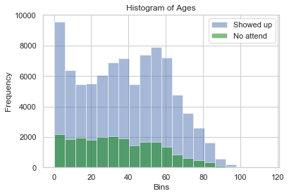

```python
# Creating a histogram to see the distribution of the ages.
df.Age[showed_up].hist(alpha=0.5, bins=20, label="Showed up")
df.Age[no_attend].hist(alpha=0.5, bins=20, color="green", label="No attend")
plt.xlabel("Bins")
plt.ylabel("Frequency")
plt.title("Histogram of Ages")
plt.legend();
```

The histogram shows that most of the patients who showed up to their scheduled appointments are either babies or patients between the ages of 50 and 60.

### Q2: Does receiving a reminder SMS associated with showing up for the scheduled appointment?

```python
# Exploring the relationship between showing up to the appointments and the mean of receiving a reminder SMS.
df_SMS=df.groupby("No_show", as_index=False).SMS_received.mean()
print(df_SMS)
```

```
  No_show  SMS_received
0      No      0.291337
1     Yes      0.438371
```

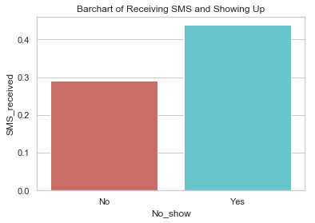

```python
# Creating a barchart of receiving a reminder SMS and showing up to the appointments to better understand the relationship.
sns.barplot(x="No_show", y="SMS_received", palette="hls", data=df_SMS).set_title('Barchart of Receiving SMS and Showing Up');
```

The barchart shows that approximately 29% of the patients who showed up to their appointments received a reminder SMS, while approximately 43% of the patients who did not show up to their appointments received a reminder SMS. Thus, there is no clear relationship between receiving a reminder SMS and showing up to the appointments.

```python
# Checking if the results are affected by the number of the patients who did or did not show up.
df.No_show.value_counts()
```

```
No     88207
Yes    22319
Name: No_show, dtype: int64
```

### Q3: Does having a scholarship associated with showing up for the scheduled appointment?

```python
# Exploring the relationship between showing up to the appointments and having a scholarship.
# PS: scholarship indicates whether or not the patient is enrolled in Brasilian welfare program.
df_Schol=df.groupby("No_show", as_index=False).Scholarship.mean()
print(df_Schol)
```

```
  No_show  Scholarship
0      No     0.093904
1     Yes     0.115507
```

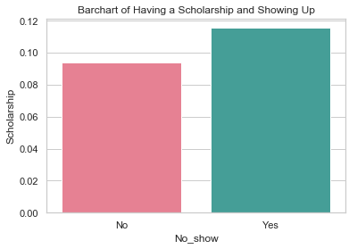

```python
# Creating a barchart of having a scholarship and showing up to the appointments to better understand the relationship.
sns.barplot(x="No_show", y="Scholarship", palette=("husl"), data=df_Schol).set_title('Barchart of Having a Scholarship and Showing Up');
```

The barchart shows that approximately 9% of the patients who showed up to their appointments had a scholarship, while approximately 11% of the patients who did not show up to their appointments had a scholarship. Thus, there is no clear relationship between having a scholarship and showing up to the appointments.

## Conclusions

> As a reminder, the main question that this project attempted to answer is: What are the factors that need to be considered in predicting if a patient will show up for their scheduled appointment?

> The analyst tryed to identify some of these factors by exploring the relationship between the dependent variable 'No_show' and the three independent variables: 'Age', 'SMS_received', and 'Scholarship'.

> The analyst found that if the patient is a baby or the age of the patient between 50 and 60, they would possibly show up to their scheduled appointments. Furthermore, there is no clear relationship found between receiving a reminder SMS and showing up to the appointments. In addition, there is no clear relationship between showing up to the appointments and having a scholarship.

> However, there are some limitations associated with the analysis of the results. The analyst, for example, did not take into account the influence of the location of the hospital and the time of the appointment over showing up for the scheduled appointment. On top of that, the findings are tentative as there is no use of any inferential statistics or machine learning while exploring the data.